# Predicting activity type using wearable device data

Wei Wang

July 20, 2015

# Introduction

Amid the latest technology development in wearable devices, large amount of data were collected about personal activities. One thing that people regularly do is quantify how much of a particular activity they do, but they rarely quantify how well they do it. In this project, we will be using data from accelerometers on the belt, forearm, arm, and dumbell of 6 participants. They were asked to perform barbell lifts correctly and incorrectly in 5 different ways. Our goal is to predict the manner in which they did the exercises (`classe`).

# Build the model

To build the machine learning model, firstly we want to look at our training data and exculde any variables that have missing values.Then we manually remove some variables apprently useless for the prediction model. Finaly, we will reshape the test dataset the same way as training dataset.

```r
library(caret,quietly = T)
library(Hmisc,quietly = T)
training <- read.csv("pml-training.csv",header = T,na.strings = c("NA", ""))
testing <- read.csv("pml-testing.csv",header = T,na.strings = c("NA", ""))
dim(training)
```

```
## [1] 19622   160
```

```r
## remove NAs
NAs <- apply(training, 2, function(x) {
    sum(is.na(x))
})

training <- training[,NAs == 0]

## remove useless variables
ex_vars <- grep("timestamp|X|user_name|new_window", names(training))

training <- training[,-ex_vars]
testing <- testing[,names(testing) %in% names(training)]
```

```r
dim(training)
```

```
## [1] 19622    54
```

To estimate out of sample errors, we partition the training dataset into two - one used to build the model (`trainDF`) and the other (`valDF`) used to estimate out of sample error.

```r
set.seed(10)
index <- createDataPartition(y = training$classe,p=0.7,list = FALSE)
trainDF <- training[index,]
valDF <- training[-index,]
```

## Visulization of features

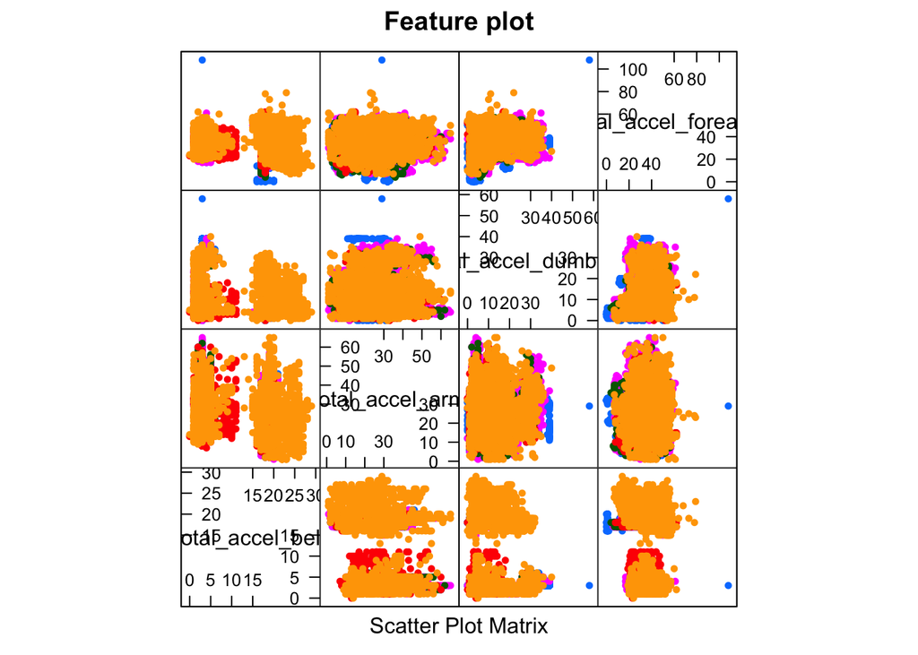

```r
# plot features
total <- which(grepl("^total", colnames(trainDF), ignore.case = F))
totalAccel <- trainDF[, total]
featurePlot(x = totalAccel, y = trainDF$classe, pch = 20, main = "Feature plot", plot = "pairs")
```

```r
# set traingControl to use CV
tc <- trainControl(method="cv",number = 5)

# rf and gbm models
set.seed(10)
model.rf <- train(trainDF$classe ~ ., method = "rf", trControl = tc,data=trainDF)

set.seed(10)
model.gbm <- train(classe ~ ., method = "gbm", trControl = tc,verbose=FALSE,data=trainDF)


model.rf
```

```
## Random Forest
##
## 13737 samples
##    53 predictor
##     5 classes: 'A', 'B', 'C', 'D', 'E'
##
## No pre-processing
## Resampling: Cross-Validated (5 fold)
##
## Summary of sample sizes: 10991, 10990, 10989, 10990, 10988
##
## Resampling results across tuning parameters:
##
##   mtry  Accuracy   Kappa      Accuracy SD   Kappa SD
##    2    0.9934482  0.9917120  0.0005778100  0.0007311714
##   27    0.9973065  0.9965931  0.0006096369  0.0007710095
##   53    0.9950496  0.9937384  0.0017582800  0.0022232900
##
## Accuracy was used to select the optimal model using  the largest value.
## The final value used for the model was mtry = 27.
```

```r
summary(model.rf)
```

```
##                 Length Class      Mode
## call                4  -none-     call
## type                1  -none-     character
## predicted       13737  factor     numeric
## err.rate         3000  -none-     numeric
## confusion          30  -none-     numeric
## votes           68685  matrix     numeric
## oob.times       13737  -none-     numeric
## classes             5  -none-     character
## importance         53  -none-     numeric
## importanceSD        0  -none-     NULL
## localImportance     0  -none-     NULL
## proximity           0  -none-     NULL
## ntree               1  -none-     numeric
## mtry                1  -none-     numeric
## forest             14  -none-     list
## y               13737  factor     numeric
## test                0  -none-     NULL
## inbag               0  -none-     NULL
## xNames             53  -none-     character
## problemType         1  -none-     character
## tuneValue           1  data.frame list
## obsLevels           5  -none-     character
```

```r
model.gbm
```

```
## Stochastic Gradient Boosting
##
## 13737 samples
##    53 predictor
##     5 classes: 'A', 'B', 'C', 'D', 'E'
##
## No pre-processing
## Resampling: Cross-Validated (5 fold)
##
## Summary of sample sizes: 10991, 10990, 10989, 10990, 10988
##
## Resampling results across tuning parameters:
##
##   interaction.depth  n.trees  Accuracy   Kappa      Accuracy SD
##   1                   50      0.7598434  0.6951715  0.007986403
##   1                  100      0.8309665  0.7860070  0.006314839
##   1                  150      0.8704940  0.8360517  0.007320919
##   2                   50      0.8833072  0.8521816  0.003570566
##   2                  100      0.9392884  0.9231649  0.005061579
##   2                  150      0.9633843  0.9536625  0.003561473
##   3                   50      0.9315001  0.9132807  0.004071085
##   3                  100      0.9724108  0.9650882  0.002103148
##   3                  150      0.9853684  0.9814906  0.002497390
##   Kappa SD
##   0.010322452
##   0.007959497
##   0.009292149
##   0.004566379
##   0.006409188
##   0.004507519
##   0.005163551
##   0.002661970
##   0.003159642
##
## Tuning parameter 'shrinkage' was held constant at a value of 0.1
##
## Tuning parameter 'n.minobsinnode' was held constant at a value of 10
## Accuracy was used to select the optimal model using  the largest value.
## The final values used for the model were n.trees = 150,
##  interaction.depth = 3, shrinkage = 0.1 and n.minobsinnode = 10.
```

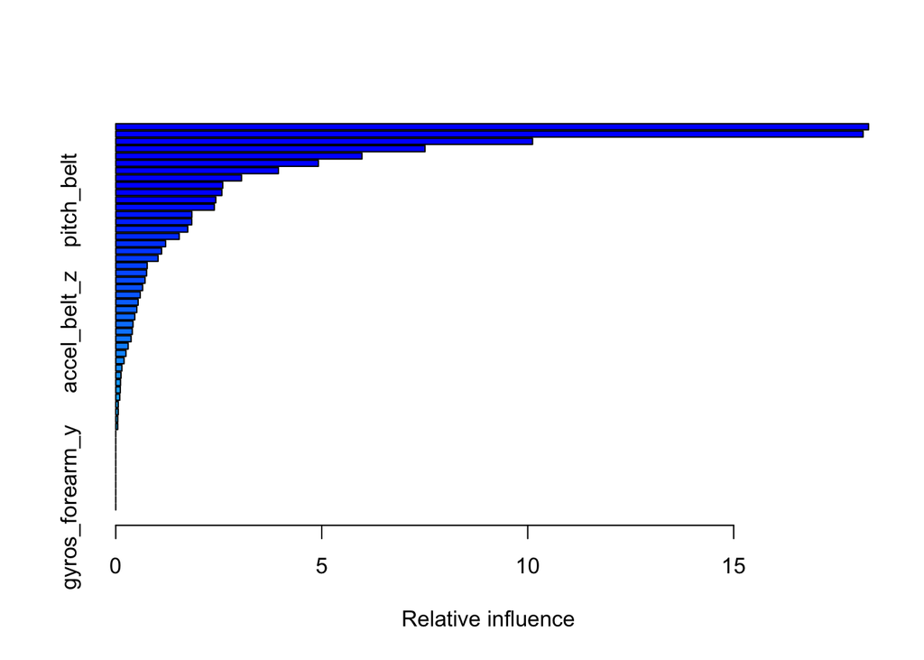

```
##                                       var     rel.inf
## roll_belt                       roll_belt 18.27379233
## num_window                     num_window 18.14120854
## pitch_forearm               pitch_forearm 10.11720160
## magnet_dumbbell_z       magnet_dumbbell_z  7.50751550
## yaw_belt                         yaw_belt  5.97626862
## magnet_dumbbell_y       magnet_dumbbell_y  4.91872962
## roll_forearm                 roll_forearm  3.94807958
## magnet_belt_z               magnet_belt_z  3.05346019
## accel_forearm_x           accel_forearm_x  2.59649104
## roll_dumbbell               roll_dumbbell  2.57500787
## pitch_belt                     pitch_belt  2.42768218
## gyros_belt_z                 gyros_belt_z  2.39230480
## accel_dumbbell_y         accel_dumbbell_y  1.84815339
## gyros_dumbbell_y         gyros_dumbbell_y  1.84474761
## accel_dumbbell_z         accel_dumbbell_z  1.74719493
## accel_dumbbell_x         accel_dumbbell_x  1.53946597
## magnet_forearm_z         magnet_forearm_z  1.20992170
## yaw_arm                           yaw_arm  1.11183354
## magnet_arm_z                 magnet_arm_z  1.02637125
## accel_forearm_z           accel_forearm_z  0.76375834
## roll_arm                         roll_arm  0.74904838
## magnet_belt_x               magnet_belt_x  0.71029011
## magnet_arm_x                 magnet_arm_x  0.65235162
## magnet_belt_y               magnet_belt_y  0.59423436
## magnet_forearm_x         magnet_forearm_x  0.54264126
## gyros_arm_y                   gyros_arm_y  0.51087931
## gyros_belt_y                 gyros_belt_y  0.46246766
## magnet_arm_y                 magnet_arm_y  0.41877165
## accel_belt_z                 accel_belt_z  0.40132070
## magnet_dumbbell_x       magnet_dumbbell_x  0.37171759
## total_accel_dumbbell total_accel_dumbbell  0.30113060
## accel_forearm_y           accel_forearm_y  0.24794997
## pitch_dumbbell             pitch_dumbbell  0.20130024
## magnet_forearm_y         magnet_forearm_y  0.14914014
## gyros_arm_x                   gyros_arm_x  0.12659986
## gyros_dumbbell_x         gyros_dumbbell_x  0.11546384
## accel_arm_z                   accel_arm_z  0.10990148
## total_accel_arm           total_accel_arm  0.09765361
## gyros_dumbbell_z         gyros_dumbbell_z  0.06045852
## total_accel_forearm   total_accel_forearm  0.06001257
## gyros_forearm_z           gyros_forearm_z  0.04913062
## accel_arm_x                   accel_arm_x  0.04834728
## total_accel_belt         total_accel_belt  0.00000000
## gyros_belt_x                 gyros_belt_x  0.00000000
## accel_belt_x                 accel_belt_x  0.00000000
## accel_belt_y                 accel_belt_y  0.00000000
## pitch_arm                       pitch_arm  0.00000000
## gyros_arm_z                   gyros_arm_z  0.00000000
## accel_arm_y                   accel_arm_y  0.00000000
## yaw_dumbbell                 yaw_dumbbell  0.00000000
## yaw_forearm                   yaw_forearm  0.00000000
## gyros_forearm_x           gyros_forearm_x  0.00000000
## gyros_forearm_y           gyros_forearm_y  0.00000000
```

```r
summary(model.gbm)
```

```r
# collect resamples
results <- resamples(list(RF=model.rf, GBM=model.gbm))
# summarize the distributions
summary(results)
```

```
##
## Call:
## summary.resamples(object = results)
##
## Models: RF, GBM
## Number of resamples: 5
##
## Accuracy
##       Min. 1st Qu. Median   Mean 3rd Qu.   Max. NA's
## RF  0.9964  0.9971 0.9975 0.9973  0.9978 0.9978    0
## GBM 0.9825  0.9833 0.9862 0.9854  0.9862 0.9887    0
##
## Kappa
##       Min. 1st Qu. Median   Mean 3rd Qu.   Max. NA's
## RF  0.9954  0.9963 0.9968 0.9966  0.9972 0.9972    0
## GBM 0.9779  0.9788 0.9825 0.9815  0.9825 0.9857    0
```

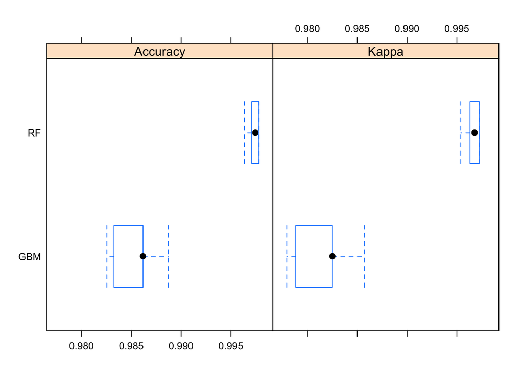

```r
# boxplots of results
bwplot(results)
```

From the comparison above, we see `rf` is slightly better than `gbm` though both models are pretty good in accuracy. For better or for worse, we will use `rf` model as our final machine learning algorithm.

# Out of sample error estimation

```r
dim(valDF)
```

```
## [1] 5885   54
```

```r
pred <- predict(model.rf, valDF)
OutSampErr <- 1 - sum(pred == valDF$classe)/length(pred)
confusionMatrix(pred,valDF$classe)
```

```
## Confusion Matrix and Statistics
##
##           Reference
## Prediction    A    B    C    D    E
##          A 1674    3    0    0    0
##          B    0 1132    3    0    0
##          C    0    3 1023    2    0
##          D    0    1    0  962    0
##          E    0    0    0    0 1082
##
## Overall Statistics
##
##                Accuracy : 0.998
##                  95% CI : (0.9964, 0.9989)
##     No Information Rate : 0.2845
##     P-Value [Acc > NIR] : < 2.2e-16
##
##                   Kappa : 0.9974
##  Mcnemar's Test P-Value : NA
##
## Statistics by Class:
##
##                      Class: A Class: B Class: C Class: D Class: E
## Sensitivity            1.0000   0.9939   0.9971   0.9979   1.0000
## Specificity            0.9993   0.9994   0.9990   0.9998   1.0000
## Pos Pred Value         0.9982   0.9974   0.9951   0.9990   1.0000
## Neg Pred Value         1.0000   0.9985   0.9994   0.9996   1.0000
## Prevalence             0.2845   0.1935   0.1743   0.1638   0.1839
## Detection Rate         0.2845   0.1924   0.1738   0.1635   0.1839
## Detection Prevalence   0.2850   0.1929   0.1747   0.1636   0.1839
## Balanced Accuracy      0.9996   0.9966   0.9980   0.9989   1.0000
```

So the out-of-sample error is estimated as 0.204%.

# Prediction on the test dataset

```r
model.pred <- as.character(predict(model.rf, testing))

pml_write_files = function(x) {
    n = length(x)
    for (i in 1:n) {
        filename = paste0("problem_id_", i, ".txt")
        write.table(x[i], file = filename, quote = FALSE, row.names = FALSE,
            col.names = FALSE)
    }
}

pml_write_files(model.pred)
```